# Central Limit Theory and the Exponential Distribution

Andrew Crisp

November 13, 2015

# Overview

Through a simulation, the Central Limit Theory will be demonstrated. The mean and variance of the exponential distribution will be simulated and compared to calculated values.

# Simulations

During the simulation, lambda will be set to a controlled 0.2. 1000 passes will be made, collecting 40 random exponential distribution samples. After collecting the sample values, the mean of each group will be collected and indexed for easy inspection.

```r
require(ggplot2)
lambda <- 0.2
nosims <- 1000
n <- 40
rexpValues <- NULL
means <- NULL
for (i in 1:nosims) rexpValues <- rbind(rexpValues,rexp(n = n, rate = lambda))
for (i in 1:nosims) means <- rbind(means, mean(rexpValues[i,]))
means <- as.numeric(means)
```

# Sample mean versus Theoretical mean

The mean of an exponential distribution is 1/lambda. This theoretical mean can be calculated easily and compared with the actual collected sample mean.

```r
calcMean <- 1/lambda
simMean <- mean(rexpValues)
CLTMean <- mean(means)
```

The calculated mean is 5.

The Central Limit Theory says that the mean of the a sample should approximate the mean of the population. The mean of all 1000 means simulated is 4.9844957.

The actual mean of all the simulated values is 4.9844957.

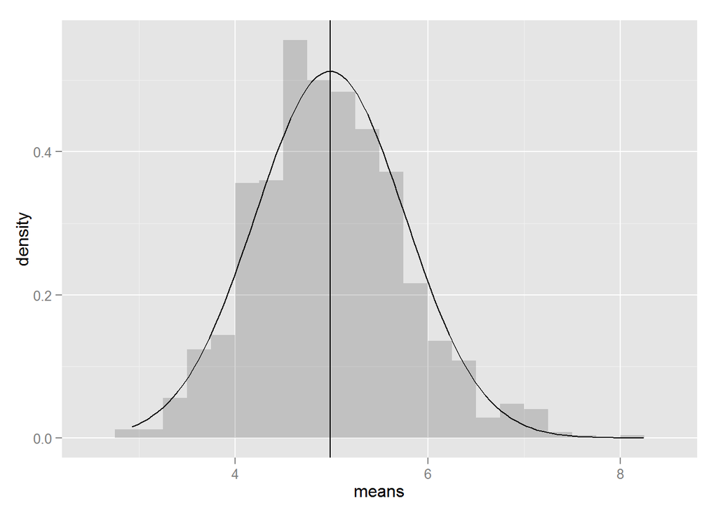

```r
#hist40Mean <- hist(means)
#fit <- seq(min(means),max(means))
#yfit <- dnorm(xfit, mean=mean(means), sd = sd(means))
#yfit <- yfit * diff(hist40Mean$mids[1:2]*length(means))
#plot(hist40Mean)
#lines(xfit,yfit)
#abline(v=mean(means), lwd=2)
ggplot() +
  aes(means) +
  geom_histogram(aes(y = ..density..), binwidth=.25, alpha=.2) +
  # geom_density(color="blue") +
  geom_vline(xintercept=mean(means)) +
  stat_function(geom="line", fun=dnorm, arg=list(mean=mean(means),sd=sd(means)))
```

# Sample variance versus Theoretical variance

Similar to the mean, the standard deviation of an exponential distribution is 1/lambda. The variance is the square of the standard deviation.

```r
calcVariance <- (1/lambda)^2
n <- 40
n40CollectionOfVariances <- NULL
for (i in 1:nosims) n40CollectionOfVariances <- rbind(n40CollectionOfVariances, var(rexpValues[i,]))
simVariance <-mean(n40CollectionOfVariances)
```

The calculated (theoretical) variance is 25.

The average variance of the simulations is 24.8117019.

```
## stat_bin: binwidth defaulted to range/30. Use 'binwidth = x' to adjust this.
```

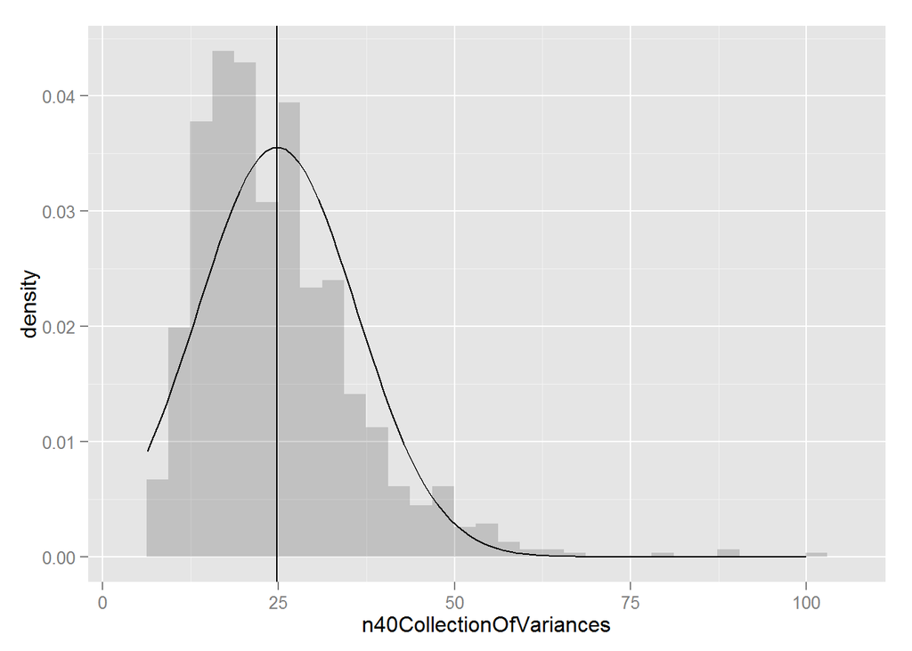

```r
#hist40Variance <- hist(n40CollectionOfVariances)
#xfit <- seq(min(n40CollectionOfVariances),max(n40CollectionOfVariances))
#yfit <- dnorm(xfit, mean=mean(n40CollectionOfVariances), sd = sd(n40CollectionOfVariances))
#yfit <- yfit * diff(hist40Variance$mids[1:2]*length(n40CollectionOfVariances))
#plot(hist40Variance)
#lines(xfit,yfit)
#abline(v=mean(n40CollectionOfVariances), lwd=2)
ggplot() +
  aes(n40CollectionOfVariances) +
  geom_histogram(aes(y = ..density..), alpha=.2) +
  # geom_density(color="blue") +
  geom_vline(xintercept=mean(n40CollectionOfVariances)) +
  stat_function(geom="line", fun=dnorm, arg=list(mean=mean(n40CollectionOfVariances),sd=sd(n40CollectionOfVariances)))
```